[figure not shown]

# Introduction to Python for Data Science

# Lecture 07: User-defined Functions

## Student Name: Lecture 07 Live HTML

## Student ID: NA

## 0.1.0 About Introduction to Python

Introduction to Python is brought to you by the **Centre for the Analysis of Genome Evolution & Function (CAGEF)** bioinformatics training initiative. This course was developed based on feedback on the needs and interests of the Department of Cell & Systems Biology and the Department of Ecology and Evolutionary Biology.

The structure of this course is a code-along style so it is 100% hands on! A few hours prior to each lecture, the materials will be avaialable for download at [QUERCUS](https://q.utoronto.ca/). The teaching materials will consist of a Jupyter Lab Notebook with concepts, comments, instructions, and blank spaces that you will fill out with Python code along with the instructor. Other teaching materials include a live version of the notebook, and datasets to import into Python - when required. This learning approach will allow you to spend the time coding and not taking notes!

As we go along, there will be some in-class challenge questions for you to solve either individually or in cooperation with your peers. Post lecture assessments will also be available (see syllabus for grading scheme and percentages of the final mark) through [DataCamp](https://Datacamp.com) to help cement and/or extend what you learn each week.

### 0.1.1 Where is this course headed?

We'll take a blank slate approach here to Python and assume that you pretty much know *nothing* about programming. From the beginning of this course to the end, we want to get you from some potential scenarios:

- A pile of data (like an excel file or tab-separated file) full of experimental observations and you don't know what to do with it.
- Maybe you're manipulating large tables all in excel, making custom formulas and pivot table with graphs. Now you have to repeat similar experiments and do the analysis again.
- You're generating high-throughput data and there aren't any bioinformaticians around to help you sort it out.
- You heard about Python and what it *could* do for your data analysis but don't know what that means or where to start.

and get you to a point where you can:

- Format your data correctly for analysis
- Produce basic plots and perform exploratory analysis
- Make functions and scripts for re-analysing existing or new data sets
- Track your experiments in a digital notebook like Jupyter!

### 0.1.2 How do we get there? Step-by-step.

In the first two lessons, we will talk about the basic data structures and objects in Python, get cozy with the Jupyter Notebook environment, and learn how to get help when you are stuck. Because everyone gets stuck - a lot! Then you will learn how to get your data in and out of Python, how to tidy our data (data wrangling), subset and merge data. We'll take a break from data wrangling to spend our fourth lecture learning how to generate exploratory data plots. Then we'll slide into using the power of python and programming to use flow control before visiting text manipulation techniques in lectures 5 and 6. Data cleaning and string manipulation is really the battleground of coding - getting your data into the format where you can analyse it. Lastly, we will learn to write customized functions to help scale up your analyses.

[figure not shown]

The structure of the class is a **code-along** style: It is fully hands on. At the end of each lecture, the complete notes will be made available in a PDF format through the corresponding Quercus module so you don't have to spend your attention on taking notes.

### 0.1.3 What kind of coding style will we learn?

There is no single path correct from A to B - although some paths may be more elegant, or more efficient than others. With that in mind, the emphasis in this lecture series will be on:

1. **Code simplicity** - learn helpful functions that allow you to focus on understanding the basic tenets of good data wrangling (reformatting) to facilitate quick exploratory data analysis and visualization.
2. **Code readability** - format and comment your code for yourself and others so that even those with minimal experience in R will be able to quickly grasp the overall steps in your code.
3. **Code stability** - while the core Python code is relatively stable, behaviours of functions can still change with updates. There are well-developed packages we'll focus on for our analyses. Namely, we'll become more familiar with the `pandas` series of packages for working with tabular data. This resource is well-maintained by a large community of developers. While not always the "fastest" approach this additional layer can help ensure your code still runs (somewhat) smoothly later down the road.

## 0.2.0 Lecture objectives

Welcome to this final lecture in a series of seven. We've previously covered data structures, data wrangling, exploratory data analysis, flow control, and most recently string search and manipulation but today we will pull from all of those areas to build our own *user-defined functions*.

At the end of this lecture we will aim to have covered the following topics:

1. Generating user-defined functions.
2. Variables and their scope.
3. Case study 1: building a transforming function.
4. Case study 2: automating data retrieval.
5. A deeper dive into data mining.

## 0.3.0 A legend for text format in Jupyter markdown

`grey background` - a package, function, code, command or directory. Backticks are also use for in-line code.  
*italics* - an important term or concept or an individual file or folder  
**bold** - heading or a term that is being defined  
blue text - named or unnamed hyperlink

`...` - Within each coding cell this will indicate an area of code that students will need to complete for the code cell to run correctly.

**Blue box:** A key concept that is being introduced

**Yellow box:** Risk or caution

**Green boxes:** Recommended reads and resources to learn Python

**Red boxes:** A comprehension question which may or may not involve a coding cell. You usually find these at the end of a section.

## 0.4.0 Lecture and data files used in this course

### 0.4.1 Weekly Lecture and skeleton files

Each week, new lesson files will appear within your JupyterHub folders. We are pulling from a GitHub repository using this [Repository git-pull link](https://jupyter.utoronto.ca/hub/user-redirect/git-pull?repo=https%3A%2F%2Fgithub.com%2Fcamok%2F2023-01-IntroPython&urlpath=tree%2F2023-01-IntroPython%2F&branch=main). Simply click on the link and it will take you to the University of Toronto JupyterHub. You will need to use your UTORid credentials to complete the login process. From there you will find each week's lecture files in the directory `/2023-01-IntroPython/Lecture_XX`. You will find a partially coded `skeleton.ipynb` file as well as all of the data files necessary to run the week's lecture.

Alternatively, you can download the Jupyter Notebook (`.ipynb`) and data files from JupyterHub to your personal computer if you would like to run independently of the JupyterHub.

### 0.4.2 Live-coding HTML page

A live lecture version will be available at [camok.github.io](https://camok.github.io/2023-01.IntroPython/index.html) that will update as the lecture progresses. Be sure to refresh to take a look if you get lost!

### 0.4.3 Post-lecture PDFs

As mentioned above, at the end of each lecture there will be a completed version of the lecture code released as a PDF file under the Modules section of Quercus.

### 0.4.4 Microsporidia infection data set description

The following datasets used in this week's class come from a preprint manuscript on bioRxiv entitled "High-throughput phenotyping of *C. elegans* wild isolates reveals specific resistance and susceptibility traits to infection by distinct microsporidia species" by [Mok et al., 2022](https://www.biorxiv.org/content/10.1101/2022.06.20.496912v1). These datasets focus on the an analysis of infection in wild isolate strains of the nematode *C. elegans* by environmental pathogens known as microsporidia. The authors collected embryo counts from individual animal in the population after population-wide infection by microsporidia and we'll spend our next few classes working with the dataset to learn how to format and manipulate it.

### 0.4.4.1 Dataset 1: /data/embryo_long_merged.csv

This is a result of our efforts (mostly) from last lecture. After transforming a wide-format version of our measurement data, we merged it with some metadata regarding our experiments and now it is ready to be worked with.

### 0.4.5 Dataset 2: sequences.tsv

This is a small example dataset that we'll use to practice some string manipulation and DNA sequence formatting.

## 0.5.0 Packages used in this lesson

`IPython` and `InteractiveShell` will be access just to set the behaviour we want for iPython so we can see multiple code outputs per code cell.

`numpy` provides a number of mathematical functions as well as the special data class of `arrays` which we'll be learning about today.

`pandas` provides the DataFrame class that allows us to format and play with data in a tabular format.

`re` provide regular expression matching functions that are similar to those found in the programming language Perl

```python
# ----- Always run this at the beginning of class so we can get multi-command output ----- #

# Access options from the iPython core
from IPython.core.interactiveshell import InteractiveShell

# Change the value of ast_node_interactivity
InteractiveShell.ast_node_interactivity = "all"

# ----- Additional packages we want to import for class ----- #

# Import the pandas package
# import pandas as pd
# import numpy as np
```

# 1.0.0 User-defined Functions

User defined functions allow you to write your own code as functions that you and others can (re)use. You could achieve similar results by copying and pasting code on-demand, but this is highly prone to errors: You may forget to replace some arguments or variables from a previous run. This may lead to serious issues that can compromise the accuracy and reliability of your code and analyses.

Also, if at some point you realized that your code had an error, you have to go back to every section and script that you wrote in order to update your code. Very tedious and risky, isn't it? Therefore, user-defined or customized functions can be very handy so you do not need to copy-paste code over and over. This is known as the DRY principle: Don't Repeat Yourself.

Here is a list of some of the advantages of writing your own functions:

- Creating a new function gives you an opportunity to name a group of statements, which makes your program easier to read, understand, and debug.
- Functions can make a program smaller by eliminating repetitive code. Later, if you make a change, you only have to make it in one place.
- Dividing a long program into functions allows you to debug the parts one at a time and then assemble them into a working whole.
- Well-designed functions are often useful for many programs. Once you write and debug one, you can reuse it.

**Disclaimer:**

User-defined functions can take time to write, depending on your Python skills and the complexity of the function that you're trying to construct. Thus, as with for loops, consider writing your own functions only when there are no publicly available, ready-to-use functions to do the task that you need to carry out. Be efficient and do not reinvent the wheel! Unless you have the luxury of time and just want to write code for fun.

## 1.1.0 Best practices

Here is where we start, and there are plenty of good reasons to start with best practices: Writing functions without following best practices is a *recipe for madness*. Among the best practices for writing your own functions, documenting your code should *always* be at the top. In the context of user-defined functions, documentation is known as **docstring**, a text that appears at the top of a function when `?` or the `help()` function are called. A well-written docstring is expected to contain (at least) the following information:

- Description of what the function does.
- Description of the arguments, if any.
- Description of the return value(s), if any.
- Description of errors raised, if any.
- Optional extra notes or examples of usage.

### 1.1.1. Docstrings formats: Numpydoc

Docstrings are written within triple double-quotes `"""`. Several docstrings formats are used by the Python community, including Numpydoc, GoogleStyle, reStructuredText, and EpyText. As with variable-naming conventions, regardless of which format you decide to use, the key is to be consistent across docstrings. In other words, pick a format and stick to it. The difference between the several formats is (mainly) in the order in which the parts of a function are documented. Other than that, the formats' contents are very similar.

Numpydoc is the most common docstring format in Python. The documentation for Numpy `array` is an example of Numpydoc docstring.

```python
import numpy as np

np.array?
```

Docstring in the Numpydoc can have sections for Description, Parameters, Returns, See Also, Notes, and Examples. If some of your function's parameters are optional, you state so by specifying it in the description of that parameter. For example, my_arg is boolean and is optional, so its docstring would look like:

Parameters: my_arg: bool, optional

To retrieve just a function's docstring, you can use the `.__doc__` attribute to get the raw docstring

```python
# grab the array docstring
np.array.__doc__
```

```
"array(object, dtype=None, *, copy=True, order='K', subok=False, ndmin=0,\n          like=None)\n\n    Create an array.\n\n    Parameters\n    ----------\n    object : array_like\n        An array, any object exposing the array interface, an object whose\n        __array__ method returns an array, o…
```

`print(.__doc__)` hides the markup syntax and makes it more readable

```python
print(np.array.__doc__)
```

```
array(object, dtype=None, *, copy=True, order='K', subok=False, ndmin=0,
          like=None)

    Create an array.

    Parameters
    ----------
    object : array_like
        An array, any object exposing the array interface, an object whose
        __array__ method returns an array, or any (nested) sequence.
        If object is a scalar, a 0-dimensional array containing object is
        returned.
    dtype : data-type, optional
        The desired data-type for the array.  If not given, then the type will
        be determined as the minimum type required to hold the objects in the
        sequence.
    copy : bool, optional
        If true (default), then the object is copied.  Otherwise, a copy will
        only be made if __array__ returns a copy, if obj is a nested sequence,
        or if a copy is needed to satisfy any of the other requirements
        (`dtype`, `order`, etc.).
    order : {'K', 'A', 'C', 'F'}, optional
        Specify the memory layout of the array. If object is not an array, the
        newly created array will be in C order (row major) unless 'F' is
        specified, in which case it will be in Fortran order (column major).
        If object is an array the following holds.

        ===== ========= ===================================================
        order  no copy                     copy=True
        ===== ========= ===================================================
        'K'   unchanged F & C order preserved, otherwise most similar order
        'A'   unchanged F order if input is F and not C, otherwise C order
        'C'   C order   C order
        'F'   F order   F order
        ===== ========= ===================================================

        When ``copy=False`` and a copy is made for other reasons, the result is
        the same as if ``copy=True``, with some exceptions for 'A', see the
        Notes section. The default order is 'K'.
    subok : bool, optional
```

[output cut: 64 more lines]

```
    Data-type consisting of more than one element:

    >>> x = np.array([(1,2),(3,4)],dtype=[('a','<i4'),('b','<i4')])
    >>> x['a']
    array([1, 3])

    Creating an array from sub-classes:

    >>> np.array(np.mat('1 2; 3 4'))
    array([[1, 2],
           [3, 4]])

    >>> np.array(np.mat('1 2; 3 4'), subok=True)
    matrix([[1, 2],
            [3, 4]])
```

Another option is to use the built-in `inspect` module, which also has many other useful functions to retrieve docstrings. Read more about this package at its [documention page](https://docs.python.org/3/library/inspect.html).

```python
import inspect

print(inspect.getdoc(np.array))
```

```
array(object, dtype=None, *, copy=True, order='K', subok=False, ndmin=0,
      like=None)

Create an array.

Parameters
----------
object : array_like
    An array, any object exposing the array interface, an object whose
    __array__ method returns an array, or any (nested) sequence.
    If object is a scalar, a 0-dimensional array containing object is
    returned.
dtype : data-type, optional
    The desired data-type for the array.  If not given, then the type will
    be determined as the minimum type required to hold the objects in the
    sequence.
copy : bool, optional
    If true (default), then the object is copied.  Otherwise, a copy will
    only be made if __array__ returns a copy, if obj is a nested sequence,
    or if a copy is needed to satisfy any of the other requirements
    (`dtype`, `order`, etc.).
order : {'K', 'A', 'C', 'F'}, optional
    Specify the memory layout of the array. If object is not an array, the
    newly created array will be in C order (row major) unless 'F' is
    specified, in which case it will be in Fortran order (column major).
    If object is an array the following holds.

    ===== ========= ===================================================
    order  no copy                     copy=True
    ===== ========= ===================================================
    'K'   unchanged F & C order preserved, otherwise most similar order
    'A'   unchanged F order if input is F and not C, otherwise C order
    'C'   C order   C order
    'F'   F order   F order
    ===== ========= ===================================================

    When ``copy=False`` and a copy is made for other reasons, the result is
    the same as if ``copy=True``, with some exceptions for 'A', see the
    Notes section. The default order is 'K'.
subok : bool, optional
```

[output cut: 64 more lines]

```
Data-type consisting of more than one element:

>>> x = np.array([(1,2),(3,4)],dtype=[('a','<i4'),('b','<i4')])
>>> x['a']
array([1, 3])

Creating an array from sub-classes:

>>> np.array(np.mat('1 2; 3 4'))
array([[1, 2],
       [3, 4]])

>>> np.array(np.mat('1 2; 3 4'), subok=True)
matrix([[1, 2],
        [3, 4]])
```

### 1.1.2 Do One Thing - but do it well

Another best practice when writing functions is the "Do One Thing" principle: each function should do one thing; one task. Instead of a big function, you can write several small ones per task, without going to the other extreme which would be fragmenting your code into a ridiculous amount of code snippets. By doing the one thing, your functions become:

- More flexible (easier to combine with other methods).
- More easily understood.
- Simpler to test.
- Simpler to debug.
- Easier to change.

Time to start writing our own functions.

## 1.2.0 Defining a function

To define a function, we need three key pieces plus the docstring:

- **Function header:** The function name is also known as the *identifier* of the function. Since a function definition is an executable statement its execution binds the function name to the function object which can be called later on using the identifier `()`.
- **Parameters:** An optional list of identifiers that get bound to the values supplied as arguments when the function is called. A function may have an arbitrary number of arguments which are separated by commas.
- **Statement(s):** Also known as the function body, are a non-empty sequence of statements executed each time the function is called. This means a function body cannot be empty, just like any indented block.
- **Docstring:** Documentation about the function

Therefore, the structure of a function is:

```python
def function_name(parameters):
    """Docstring information
    """
    statement(s)
```

## 1.3.0 Functions with no parameters

Let's make our first function `print_square()` but we'll keep it simple to start before building up to more complex functions. Without any parameters, a function will *usually* run without any external information and therefore will return the same output in most cases. Of course that assumes you're not making a random number generator - which we aren't!

```python
def print_square(): # function header
    """Return the square of an integer or float
    Parameters: None
    """
    new_value = 4 ** 2 # function body. 4 to the power of 2, or 4 squared
    print(new_value)
```

```python
# Show us the docstring of the function

help(print_square)
```

```
Help on function print_square in module __main__:

print_square()
    Return the square of an integer or float
    Parameters: None
```

Because this function has no parameters, the output will always be 16

```python
# Call on our new function
print_square()
```

```
16
```

## 1.4.0 Functions with a single parameter

A hard-coded function such as the one we defined above can be useful in very few occasions. Adding parameters would make it more flexible since it could alter its output based on user-provided input.

Let's redefine `print_square()` but this time include a parameter `value` that we will use as the base to our squaring function.

```python
def print_square(value):
    """Print the square of an integer or float
    Parameters
    ----------
    value: integer or float, the value to be squared

    Returns
    -------
    out : prints an integer or float, the value ** 2
    """
    new_value = value ** 2 # value to the power of 2, or value squared
    print(new_value)
```

This time, running **square()** without parameters will throw a **TypeError**

```python
# What happens if we just run square()?
print_square()
```

```
---------------------------------------------------------------------------
TypeError                                 Traceback (most recent call last)
Input In [11], in <cell line: 2>()
      1 # What happens if we just run square()?
----> 2 print_square()

TypeError: print_square() missing 1 required positional argument: 'value'
```

```python
# Let's use our function with an integer input
print_square(4)
```

```
16
```

The function now works with any integer or float...

```python
print_square(8.5)
```

```
72.25
```

but not strings!

```python
print_square('string')
```

```
---------------------------------------------------------------------------
TypeError                                 Traceback (most recent call last)
Input In [14], in <cell line: 1>()
----> 1 print_square('string')

Input In [10], in print_square(value)
      1 def print_square(value):
      2     """Print the square of an integer or float
      3     Parameters
      4     ----------
   (...)
      9     out : prints an integer or float, the value ** 2
     10     """
---> 11     new_value = value ** 2 # value to the power of 2, or value squared
     12     print(new_value)

TypeError: unsupported operand type(s) for ** or pow(): 'str' and 'int'
```

A parameter is what you add to the function headers. When using the function, those parameters are referred as arguments.

### 1.4.1 Function parameters can have a default argument

When we tried to run `print_square()` without providing a value, it generated a **TypeError** since we were not assigning an appropriate object to the parameter `value`. You may have noticed throughout this course that a number of the functions and methods we use have *default* values for some of their parameters. These are also called *default arguments* for the function or *optional arguments* when calling the function. This essentially makes the parameter optional for the user, and provides a default behaviour to the function itself.

You can do the same by assigning default values to your user-defined functions too. Let's update `print_square()` to have a default `value`.

```python
# Update our function to have a default value
def print_square(value = 2):
    """Print the square of an integer or float
    Parameters
    ----------
    value: integer or float, the value to be squared

    Returns
    -------
    out : prints an integer or float, the value ** 2
    """
    new_value = value ** 2 # 4 to the power of 2, or 4 squared
    print(new_value)

# Now we can call it without parameters
print_square()

# Or with
print_square(3)
```

```
4
9
```

**Define default arguments after non-default parameters:** You may come across a case where you have *some parameters* for which you can assign a default arguments and others parameters which cannot be given a default value. It is important that when defining your function, that all non-default parameters are defined *before* any default arguments. Otherwise, Python will throw an error.

## 1.5.0 Use the `return` statement to pass an object reference back from your function

Instead of printing, we can `return` the final value of our function. The `return` statement both *ends* a function and *passes a reference to an object* (integer, list, or other items) that has a meaning for both humans and computers. In contrast, when we call on `print()`, it only prints a string for the human eye, but what is being printed means nothing to the program.

Let's make a new function, `return_square()` by replacing our `print()` call with a `return` statement.

```python
# Update square() to pass a return value instead of print() a result
def return_square(value):
    """Return the square of an integer or float
    Parameters
    ----------
    value: integer or float, the value to be squared

    Returns
    -------
    out : integer or float, the value ** 2
    """
    new_value = value ** 2 # value to the power of 2, or value-squared
    return new_value # return our value
```

```python
# Run our new return_square() function
return_square(8)
```

```
64
```

```python
# Can we access new_value?
new_value
```

```
---------------------------------------------------------------------------
NameError                                 Traceback (most recent call last)
Input In [18], in <cell line: 2>()
      1 # Can we access new_value?
----> 2 new_value

NameError: name 'new_value' is not defined
```

### 1.5.1 Assign the object from your function to retain it in memory

We attempted to access `new_value` which only exists within `square()`. It does not exist in memory after returning the reference. After this, nothing is holding onto the object, and thus it disappears from memory. In order to retain the output from `return_square()`, we need to assign it to a variable.

```python
# Assign our function's result to a variable
my_new_value = return_square(8)

print(my_new_value)
```

```
64
```

### 1.5.2 A function *always* returns an object

Recall our function `print_square()` which did not contain an explicit `return` statement. Instead it ended on a `print()` statement which still showed us the value of our squaring function. In the case of a function that completes *without* a `return` statement, Python will default to returning the `None` object.

That's right, a function will *always* return an object - either by explicit call or implicitly by design. Let's check back on our `print_square()` function.

```python
# Let's check on the object type returned by print_square()
type(print_square(4))
```

```
16
```

```
NoneType
```

Here's another example where we literally do nothing with our function!

```python
def do_nothing():
    pass # tells Python to "keep going" but there is nothing to be done

print(do_nothing())
```

```
None
```

Remember that the function body is a non-empty sequence of statements. In the example above, the `pass` statement is an null operation - when you execute it, nothing happens.

## 1.6.0 Add flow control to your functions

Functions are self-contained portions of code that can look, for the most part, like what we've been learning over the last five lectures. That means you can add loops, flow control statements, and even calls to other packages, modules, and user-defined functions within your own function.

Let's use some `if` and `else` statements in a new function.

```python
# Define a new function
def many_types(x):
    """ Check if a value is less than zero or not
    Parameters
    ----------
    x: integer or float, the value we are checking

    Returns
    -------
    out: String, a statement about whether or not the value it less than 0
    """

    if x < 0:
        return "Yes, x is less than 0!"
    else:
        return 'nope'

# Check our new function with 1
print(many_types(1))

# and -1
print(many_types(-1))
```

```
nope
Yes, x is less than 0!
```

## 1.7.0 Functions with multiple parameters

We've already worked with many functions that take in multiple parameters. Defining one is not much harder. Simply include additional parameters separated by a `,`. Also, try to give your parameters some meaningful names while you're at it.

```python
# Define a new function that extends return_square()
def raise_to_power(base_value = 1, exponent_value = 1):

    # generate a value to return
    result = base_value ** exponent_value

    # Can we return just the calculation as a result?
    return result
#     return (base_value ** exponent_value)
```

```python
# Use raise_to_power and name the parameters
raise_to_power(exponent_value = 2, base_value = 3)
```

```
9
```

### 1.7.1 Assign your function arguments to specific parameters

Did you notice that we swapped the positions of the two arguments when we called `raise_to_power()`? It is possible to change the order of the arguments without affecting the results *if* you use the name of the parameters, in this case, `base_value` and `exponent_value`. These are also known as **keyword arguments** as we are using keywords (rather than positions) to identify how our argument should be assigned. If you do not include keyword arguments in your function call, Python will assign the arguments in the **positional** order *defined* by your function.

```python
# Raise 2 to the power of 3
raise_to_power(2, 3)
```

```
8
```

Here is a function that returns the dot product of two matrices

```python
# Define our dot-product function
def dot_product(A, B): # two parameters
    """Performs matrix multiplication"""
    result = np.dot(A,B)
    return result
```

```python
import numpy as np

matrix_1 = np.array([[1,2],
                     [3,4]])

matrix_2 = np.array([[5,6],
                     [7,8]])

dot_product(A = matrix_2, matrix_1) # two arguments
```

```
  Input In [29]
    dot_product(A = matrix_2, matrix_1) # two arguments
                                      ^
SyntaxError: positional argument follows keyword argument
```

**Mixing Positional and Keyword arguments:** You may be tempted to mix both positional and keyword argumetns. This is perfectly acceptable - as long as you follow two rules: 1) positional arguments are provided **before** keyword arguments; and 2) You cannot assign arguments more than once to the same parameter. Keep this in mind!

## 1.8.0 Calling functions with an arbitrary number of arguments

Sometimes you may not know *how many* arguments a user will pass to your function. Like the `print()` function, there is no limit to how many strings are passed along to function. How can we define a function to account for this kind of uncertainty?

### 1.8.1 Use the unpacking operator `*` to create an arbitrary number of *positional* arguments

You can define functions that can take any number of (positional) arguments by adding `*args` as the only parameter - the syntax is the asterisk (`*`); `args` is just a word used by convention. Recall that we've seen this variable usage before with the unpacking/packing operator back in lecture 05? It's back to help pack multiple arguments into a single parameter.

Be aware that `*args` *cannot* be assigned default arguments of any kind; just use it *as-is*. The example below runs a `print()` inside a for loop on every argument passed to the function.

```python
# Define a function that contains a for loop that prints the unpacked arguments
# args will be a tuple containing all values that are passed in
def func(*args):
    for i in args:
        print(i)

 # Calling it with 3 arguments
func(1, 2, 3, 5, 6,9)
```

```
1
2
3
5
6
9
```

### 1.8.2 Use the unpacking operator `*` to pass elements from an iterable

As you've probably guessed by now, you can also pass values to `func()` as a list or other iterable. The key to treating each element separately is to use the `*` unpacking operator here as well. It will break out each element of the list into a separate object assigned to `*args` - which itself is a tuple object.

```python
# Make a list of arguments
list_of_arg_values = [1, 2, 3]

# Run func() using the list as-is
print("Run func() without unpacking values")
func(list_of_arg_values)

print("\nRun func() with unpacked values")
# Run func() with the unpacked list
func(*list_of_arg_values)
```

```
Run func() without unpacking values
[1, 2, 3]

Run func() with unpacked values
1
2
3
```

You can also pass a predefined array preceded by an asterisk.

```python
import numpy as np

array_1 = np.array([1, 2, 3, 4])

func(*array_1) # prints each element separately, as you would expect when the function was written
```

```
1
2
3
4
```

### 1.8.3 Use `**` to assign *arbitrary keyword arguments*

In our above example we were using positional arguments because we were not naming any of the values explicity in the `func()` call. In section 1.7.0 we assigned parameter values by their *keywords*.

In case you need a function with an arbitrary number of **k**ey**w**ords, `**kwargs` will take care of that for you. `**kwargs` allows you to handle named arguments that have not been defined in advance. This means you could send an arbitrary (optional) group of named arguments to your function. This also serves the purpose of shortening the defining header for your function - especially if you plan to have a lot of parameters. Much like using `*args` this also provides some flexibility to your function in cases where the amount of information you need can vary by situation.

Again the key to making this work is with `**` in your function definition. `kwargs` is simply the standard naming convention but not *strictly* required as the variable name.

| While the idea of the `*` and `**` unpacking operators can be confusing, they are an extremely powerful bit of syntax. |
| --- |

Here is a function that returns a dictionary key:value pairs

```python
# Define our dictionary
dictionary_aminoacids = {"Alanine": {"Ala", "A",  "GCA GCC GCG GCT"},
                         "Cysteine": {"Cys", "C", "TGC, TGT"},
                         "Aspartic acid": {"Asp", "D", "GAC GAT"},
                         "Glutamic acid": {"Glu", "E", "GAA GAG"},
                         "Phenylalanine": {"Phe", "F", "TTC TTT"},
                         "Glycine": {"Gly", "G", "GGA GGC GGG GGT"},
                         "Histidine": {"His", "H", "CAC CAT"},
                         "Isoleucine": {"Ile", "I", "ATA ATC ATT"},
                         "Lysine": {"Lys", "K", "AAA AAG"},
                         "Leucine": {"Leu", "L", "TTA TTG CTA CTC CTG CTT"},
                         "Methionine": {"Met", "M" "ATG"},
                         "Asparagine": {"Asn", "N", "AAC AAT"},
                         "Proline": {"Pro", "P", "CCA CCC CCG CCT"},
                         "Glutamine": {"Gln", "Q", "CAA CAG"},
                         "Arginine": {"Arg", "R", "AGA AGG CGA CGC CGG CGT"},
                         "Serine": {"Ser", "S", "AGC AGT TCA TCC TCG TCT"},
                         "Threonine": {"Thr", "T", "ACA ACC ACG ACU"},
                         "Valine": {"Val", "V", "GTA GTC GTG GTT"},
                         "Tryptophan": {"Trp", "W", "TGG"},
                         "Tyrosine": {"Tyr", "Y," "TAC TAT"}
                        }
```

```python
# Make a function with the **kwargs parameter
def func(**kwargs): # kwargs will be a dictionary containing the names as keys and the values as values

    # Generate an iterator from the kwargs dictionary
    for key, value in kwargs.items():
        # Print the values with the .format function substitute
        print('{0} = {1}'.format(key, value))
```

```python
# Call our function and pass along our amino acid dictionary
func(**dictionary_aminoacids)
```

```
Alanine = {'GCA GCC GCG GCT', 'Ala', 'A'}
Cysteine = {'C', 'Cys', 'TGC, TGT'}
Aspartic acid = {'Asp', 'GAC GAT', 'D'}
Glutamic acid = {'E', 'GAA GAG', 'Glu'}
Phenylalanine = {'Phe', 'F', 'TTC TTT'}
Glycine = {'G', 'Gly', 'GGA GGC GGG GGT'}
Histidine = {'His', 'CAC CAT', 'H'}
Isoleucine = {'ATA ATC ATT', 'I', 'Ile'}
Lysine = {'Lys', 'AAA AAG', 'K'}
Leucine = {'Leu', 'L', 'TTA TTG CTA CTC CTG CTT'}
Methionine = {'Met', 'MATG'}
Asparagine = {'AAC AAT', 'Asn', 'N'}
Proline = {'CCA CCC CCG CCT', 'P', 'Pro'}
Glutamine = {'Gln', 'CAA CAG', 'Q'}
Arginine = {'R', 'Arg', 'AGA AGG CGA CGC CGG CGT'}
Serine = {'S', 'Ser', 'AGC AGT TCA TCC TCG TCT'}
Threonine = {'Thr', 'T', 'ACA ACC ACG ACU'}
Valine = {'V', 'GTA GTC GTG GTT', 'Val'}
Tryptophan = {'W', 'TGG', 'Trp'}
Tyrosine = {'Y,TAC TAT', 'Tyr'}
```

### 1.8.3.1 Yes, `**kwargs`, you *are* a dictionary

In our above examples we created a dictionary object `dictionary_aminoacids` and passed that to the function with the `**` operator. Is this the reason why we can treat `kwargs` as a dictionary object? **No**.

Regardless of how we pass arguments to it through our function, the `**kwargs` parameter *is a dictionary object*. That means when we try to generate an iterator from it, it follows the same rules.

1. By default, the dictionary creates an iterator of keywords.
2. You can use pull specific iterator information from it using `keys()`, `values()`, and `items()` methods.

```python
# Let's use a few different keywords and see how func works
func(first = 1, second = 2, third = "three")
```

```
first = 1
second = 2
third = three
```

```python
# Make a function with the **kwargs parameter
def func(**kwargs): # kwargs will be a dictionary containing the names as keys and the values as values

    # Generate a value iterator from the kwargs dictionary
    # Are we doing this correctly?
    for value in kwargs:
        # Print the values from kwargs
        print(value) # Oh no, it's the hash!

# Test our new function
func(**dictionary_aminoacids)
```

```
Alanine
Cysteine
Aspartic acid
Glutamic acid
Phenylalanine
Glycine
Histidine
Isoleucine
Lysine
Leucine
Methionine
Asparagine
Proline
Glutamine
Arginine
Serine
Threonine
Valine
Tryptophan
Tyrosine
```

## 1.9.0 Lambda (In-line/Anonymous) Functions

In Lectures 05 and 06 we encountered the `lambda` keyword which creates an in-line function that contains a single expression. Recall that an expression can be evaluated to a value while the lambda function cannot contain *statements*. The value of this expression is what the function returns when invoked.

Consider the following function, `greeting()` which we will define formally.

```python
# Define a function called greeting
def greeting():
    return "Hello"

# Call on our greeting
greeting()
```

```
'Hello'
```

This particular function can also be written as a lambda function as follows:

```python
greet_me = lambda: "Hello"

greet_me()
```

```
'Hello'
```

### 1.9.1 Keep your lambda function anonymous or define a proper function

In the above example and in lecture 06 we saw some examples where we assigned our lambda function to a variable. This was done to help set up our examples for clarity when the lambda function was especially long.

The purpose of the lambda function, however, is to remain *anonymous*. This is for a number of reasons including transparency for those reading your code. Notice there is no docstring setup in your lambda function which means it is not simply queried when someone is reading through your code. If you have assigned your lambda elsewhere, a reader will not easily know its purpose. Whereas inserting the lambda function as it is meant to be, inline with your code, makes its purpose far easier to ascertain.

**Question**: What if I keep using the same or similar lambda code in different parts of my code?

**Answer**: Refactor your work and make a function that you can call on *specifically*. It will reduce potential errors and simplify your code in the long run. Do not assign your lambda to a variable.

Here is a simple anonymous function that shows clearly how lambda works.

```python
# Note our use of the map function?
list(map(lambda x: x * 2, [1, 2, 3, 4, 5]))
```

```
[2, 4, 6, 8, 10]
```

### 1.9.2 Use `map()` to link objects to functions

In our above code, `x` Takes the value of each element in the list and multiplies it by 2. The `list( )` and `map( )` are there just to let us see the output of the in-line function. Somehow it resembles a for loop, don't you think?

The `map()` function takes on the form:

```
map(function, iterable[, iterable1, iterable2, ..., iterablen])
```

and applies the `function` object to each iterable within the list. This could be a pre-defined function, method or other Python "callable" but it is called without the `()` parentheses OR it could be an anonymous lambda function as we saw above. The `map()` function returns a type of *iterator* with the transformed elements. This takes the place of using an explicit `for` loop but you still have to deal with the iterator after it's returned.

Here's an example of `map()` on it's own.

```python
# Map our square function to an integer list
squared = map(return_square, [2,4,6,8])

# What is returned
type(squared)

# Unpack the iterator
print(*squared, sep=", ")
```

```
map
```

```
4, 16, 36, 64
```

```python
# OR Assign it to a list
squared = map(return_square, [2,4,6,8])

list(squared)
```

```
[4, 16, 36, 64]
```

### 1.9.3 Use `filter()` to link an iterable to a filtering function

Much like `map()`, the `filter()` function (not to be confused with `pandas.DataFrame.filter()`) can be used to quickly filter through a single iterable. While some objects that we've worked with can be filtered on an element-by-element basis (Numpy arrays and Pandas DataFrames), core Python iterables haven't been as easily filtered... until now!

The `filter()` function takes on the form:

```
    filter(function, iterable)
```

and applies `function` which is a decision function typically returning a boolean result. While there are other use-cases for `filter()` we won't get into those today. Unlike `map()`, the `filter()` function can only evalulate a single iterable but it will still return an iterator that maps the function to iterable elements to produce a boolean result for each. You can then treat this iterator like any other to evaluate the iterable elements individually or as a whole.

And yes, our `function` can be a `lambda` function too! The following code combines `filter()` with a `lambda` function to output each element of the list that starts with the letter "d".

```python
# Let's list our favourite animals
list_1 = ['wolf', 'sheep', 'duck', 'dolphin']

# filter returns an iterator yielding those items of iterable for which function(item) is true.
list(filter(lambda x: x.startswith('d'), list_1))
```

```
['duck', 'dolphin']
```

**Section 1.0.0 Comprehension Question:** The following function **comp_func** appears to be lacking any coding comments! Take a moment to decipher what it does and determine what the output should be if we use a list of numbers: 2, 5, 8 and the keywords cum_sum (set to True), and product (set to False).

```python
# Make a function with the *args and **kwargs parameter
def comp_func(*args, **kwargs):

    for key in kwargs:

        if(key == "cum_sum" and kwargs[key] == True):
            print("The cumulative sum of *args is:", sum(args))
        elif (key == "product" and kwargs[key] == True):
            product = 1
            for i in args:
                product = product * i
            print("The combined product of *args is:", product)
        else:
            print("Function", key, "was not activated")
```

## Answer:

# 2.0.0 Scope and what the kernel remembers

Up until now, we've been moving through our code without a care in the world. Recall that deep in the background, every time we declare a variable, it is assigned a place in memory. Whenever we assign an object to a variable, it acts as a tether to wherever that object exists in memory. We've called this lifeline the *reference* to the object. When we re-assign a variable to a new object, that original link is essentially destroyed.

In Python, and most other modern programming languages, whenever all references to an object have been destroyed, the object itself is (eventually) removed from memory. As another example, we saw instances of scope usage when declaring variables just outside a for loop. While things run slightly differently in the Jupyter Notebook, here are the general rules of scoping in Python.

## 2.1.0 The scope of variables is tied to when/where they are declared

Scope can refer to multiple things but in Python it primarily is focused on

1. Namespaces - how the Python interpreter recognizes variables in different parts of the program.
2. Memory access - how a Python object exists in memory, how it can be accessed, and how long it can remain there.

Both are somewhat intertwined within the use of *scope* which changes when we use functions.

In a very simplified way, functions can be thought of as separate rooms in a house or sandboxes in a playground. When we call on these functions, we are entering a clean version of these rooms which are built with some knowledge of the basic house architecture.

- The main program/script is somewhat like a person in the house that is navigating from room to room based on a set of instructions.
- When the program first enters the house, it is given a (Global) notepad to take notes (like variables).
- When a program wanders into a new room (ie a function) it is provided a new (local) notepad that contains some information (like arguments) and it can use this notepad to write about any *new* variables it encounters.
- If it sees anything in this new room that pertains to the outside area, it can potentially write it down on the Global notepad if the permissions/circumstances are right. As a form of best practices, the program should never try to do this from within a function/room.
- If the program is asked information about a variable, it will begin with the local notepad and, if it finds nothing, it will move to the global notepad.
- If the program is specifically asked to return information, it will use the Global notepad as well.
- When it leaves a room, it must leave behind the local notepad.

Thus a variable is usually either **global** or **local** in scope. If it is local, then the information about it simply disappears at the end of the function. The scope of a variable can usually be considered as part of the same indentation of a function's section. After you've exited that section, anything explicitly declared within (ie new variables from that section) will be released from memory unless it has been passed on in a return statement.

Of course, Python also includes an **encapsulating or non-local** scope that allows named variables in nested functions to be seen by their encapsulating scope (like a room within a room). There are also other keywords that allow a program to see the global scope from a local context. We can't `*` (unpack) all of that here.

**Scope isn't just a mouthwash:** Learn more about Python scoping rules [here](https://realpython.com/python-scope-legb-rule/).

**Why is scope important?**

Understanding the basics of this concept will save you a lot of troubles down the road as you make more and more complex programs. You'll learn to avoid declaring variables in the wrong place, or trying to access ones that no longer exist in your scope. Let's revisit our examples from above.

```python
# A quick example about scope and namespaces

global_value = 100

def scoping_func():

    local_value = 42

    print("We can access global: {} and local: {} values".format(global_value, local_value))

# call on our function
scoping_func()
```

```
We can access global: 100 and local: 42 values
```

## 2.2.0 You can reuse the same variable names in different scopes

We've already seen this happening in our previous examples of `print_square()` and `return_square()`. In both cases we used the same variable name `value` without any issue. That's because each of those functions has their own *namespace* and neither can interact with each other, in the way they've been coded.

Let's try a more complex example where we are reusing a global variable inside a local context. Let's alter the value of `global_value` in our example from within the function by assigning it as an integer.

```python
# You can reuse variable names when changing scope.
global_value = 100

def scoping_func():

    local_value = 42
    global_value = 0 # We're actually defining a new variable locally

    print("We can alter global: {} and local: {} values".format(global_value, local_value))

# call on our function
scoping_func()
print("But outside the function global_value is still {}".format(global_value))
```

```
We can alter global: 0 and local: 42 values
But outside the function global_value is still 100
```

### 2.2.1 You cannot directly alter a global variable from a local context (usually)

Yes, you can assign a globally declared variable's name to a locally declared variable but you cannot directly change the value of the global variable. This comes down to namespaces again and the order of operations when we try to assign a variable. Let's do one last example and see what happens when we try to update the value of `global_value`.

```python
# Try to update global_value from inside your function
global_value = 100

def scoping_func():

    local_value = 42
    global_value = global_value + 1 # Let's increment global_value by 1

    print("We can alter global: {} and local: {} values".format(global_value, local_value))

# call on our function
scoping_func()
print("But outside the function global_value is still {}".format(global_value))
```

```
---------------------------------------------------------------------------
UnboundLocalError                         Traceback (most recent call last)
Input In [53], in <cell line: 12>()
      9     print("We can alter global: {} and local: {} values".format(global_value, local_value))
     11 # call on our function
---> 12 scoping_func()
     13 print("But outside the function global_value is still {}".format(global_value))

Input In [53], in scoping_func()
      4 def scoping_func():
      6     local_value = 42
----> 7     global_value = global_value + 1 # Let's increment global_value by 1
      9     print("We can alter global: {} and local: {} values".format(global_value, local_value))

UnboundLocalError: local variable 'global_value' referenced before assignment
```

## 2.3.0 Alter global variables by assignment in a global scope

Unfortunately we cannot run from this error. It's a Python design choice. When Python compiles all of the code into a computer-level language it builds the namespace and sees `global_value = ...` within the function. This means it will treat `global_value` as a local variable and even if we broke up the assignment moved it around, this fact will not change.

If you really need to alter `global_value` you'll want to pass it in as an argument and return a value instead that you can assign directly to `global_value`. This is the correct way to accomplish altering a global variable within a function.

```python
# Pass your variable and re-assign it as a function's output

global_value = 100

def scoping_func(global_value):

    local_value = 42
    return_value = global_value + local_value # Let's increment global_value by 1

    print("We can see global: {} and local: {} values".format(global_value, local_value))
    return return_value

# call on our function
global_value = scoping_func(global_value)
print("And re-assign global_value to {}".format(global_value))
```

```
We can see global: 100 and local: 42 values
And re-assign global_value to 142
```

| Now that you're ready, it's time to put it all together with some examples |
| --- |

# 3.0.0 Case Study 1: A string transformation function

Here is an example of a user-defined function using data from lecture 6 (Regular Expressions). The starting point was a DNA sequence.

Here we'll also use the `\` as a form of line-continuation. Unlike the `'''` triple-quote, this **will not insert** additional newlines into the string.

```python
DNA = 'GCGTTGCTGGCGTTTTTCCATAGGCTCCGCCCCCCTGACGAGCATCACAAAAATCGACGCGGTGGCGAAACCCGACAGGACTATAAAGATACCAGGCGTTTCCCCCTGGAA'\
      'GCTCCCTCGTGTTCCGACCCTGCCGCTTACCGGATACCTGTCCGCCTTTCTCCCTTCGGGAAGCGTGGCTGCTCACGCTGTACCTATCTCAGTTCGGTGTAGGTCGTTCGC'\
      'TCCAAGCTGGGCTGTGTGCCGTTCAGCCCGACCGCTGCGCCTTATCCGGTAACTATCGTCTTGAGTCCAACCCGGTAAAGTAGGACAGGTGCCGGCAGCGCTCTGGGTCAT'\
      'TTTCGGCGAGGACCGCTTTCGCTGGAGATCGGCCTGTCGCTTGCGGTATTCGGAATCTTGCACGCCCTCGCTCAAGCCTTCGTCACTCCAAACGTTTCGGCGAGAAGCAGG'\
      'CCATTATCGCCGGCATGGCGGCCGACGCGCTGGGCTGGCGTTCGCGACGCGAGGCTGGATGGCCTTCCCCATTATGATTCTTCTCGCTTCCGGCGGCCCGCGTTGCAGGCC'\
      'ATGCTGTCCAGGCAGGTAGATGACGACCATCAGGGACAGCTTCAACGGCTCTTACCAGCCTAACTTCGATCACTGGACCGCTGATCGTCACGGCGATTTATGCCGCACATG'\
      'GACGCGTTGCTGGCGTTTTTCCATAGGCTCCGCCCCCCTGACGAGCATCACAAACAAGTCAGAGGTGGCGAAACCCGACAGGACTATAAAGATACCAGGCGTTTCCCCCTG'\
      'GAAGCGCTCTCCTGTTCCGACCCTGCCGCTTACCGGATACCTGTCCGCCTTTCTCCCTTCGGGCTTTCTCAATGCTCACGCTGTAGGTATCTCAGTTCGGTGTAGGTCGTT'\
      'CGCTCCAAGCTGACGAACCCCCCGTTCAGCCCGACCGCTGCGCCTTATCCGGTAACTATCGTCTTGAGTCCAACACGACTTAACGGGTTGGCATGGATTGTAGGCGCCGCC'\
      'CTATACCTTGTCTGCCTCCCCGCGGTGCATGGAGCCGGGCCACCTCGACCTGAATGGAAGCCGGCGGCACCTCGCTAACGGCCAAGAATTGGAGCCAATCAATTCTTGCGG'\
      'AGAACTGTGAATGCGCAAACCAACCCTTGGCCATCGCGTCCGCCATCTCCAGCAGCCGCACGCGGCGCATCTCGGGCAGCGTTGGGTCCT'

# Output our DNA sequence
DNA
```

```
'GCGTTGCTGGCGTTTTTCCATAGGCTCCGCCCCCCTGACGAGCATCACAAAAATCGACGC…'
```

To translate that **DNA** into **mRNA**, we wrote a `lambda` function

```python
import re

# Translate our DNA to mRNA
mRNA = re.sub('.', # pattern
              lambda m: {'G':'C', 'C':'G', 'A':'U', 'T':'A'}.get(m.group(), "X"), # repl
              DNA # string
             )
# this does what we wanted

# Show the output of our lambda function
mRNA
```

```
'CGCAACGACCGCAAAAAGGUAUCCGAGGCGGGGGGACUGCUCGUAGUGUUUUUAGCUGCG…'
```

## 3.1.0 Reviewing the structure of our code

Let's break down the lambda function above:

- `re.sub( )` takes the following arguments (in the order they appear): `pattern`, `repl`, `string`. Here are each one of the arguments we are passing:
  - `pattern` = `.`, which as you know, stands for "any character" is the regular expression we want to use to identify our pattern
  - `repl` = replacement string which is what we are writing as a lambda function. It will find the keys and replace them with their corresponding values.
  - `string` = DNA is the string that we want to search and modify.
- The entire lambda function is contained within `re.sub( )`. Notice that we did not save the function; we simply use it "on the fly" to perform the translation of `DNA` into `mRNA`.
- `m` is a placeholder that can take any form (Python object). In this case, `m` is a `re.Match()` object which we know has the `group()` method to get the string sequence that matched our pattern.
- The `group( )` method becomes an argument for the dictionary `.get( )` which will return the `value` of our key `m.group()`.

After translation into mRNA, we further translated the ribonucleotide sequence into amino acids based on their codons. For that purpose, we created a dictionary with codons as keys and encoded amino acids as values.

```python
# mRNA to Protein
translation_aminoacids = {
    'UUU':'F', 'UUC':'F', # Phenylalanine
    'UUA':'L', 'UUG':'L', 'CUU':'L', 'CUC':'L', 'CUA':'L', 'CUG':'L', # Leucine
    'AUU':'I', 'AUC':'I', 'AUA':'I', # Isoleucine
    'AUG':'M', # Methionine
    'GUU':'V' , 'GUC':'V', 'GUA':'V', 'GUG':'V', # Valine
    'UCU':'S', 'UCC':'S', 'UCA':'S', 'UCG':'S', # Serine
    'CCU':'P', 'CCC':'P', 'CCA':'P', 'CCG':'P', # Proline
    'ACU':'U', 'ACC':'U', 'ACA':'U', 'ACG':'U', # Threonine
    'GCU':'A', 'GCU':'A', 'GCA':'A', 'GCG':'A', # Alanine
    'UAU':'Y', 'UAC':'Y', # Tyrosine
    'UAA':'', 'UAG':'', 'UGA':'',# Stop. We will translate stop codons into nothing for this excercise
    'AUG':'START', # Start
    'CAU':'H', 'CAC':'H', # Histidine
    'CAA':'Q', 'CAG':'Q', # Glutamine
    'AAU':'N', 'AAC':'N', # Asparagine
    'AAA':'K', 'AAG':'K', # Lysine
    'GAU':'D', 'GAC':'D', # Aspartic acid
    'GAA':'E', 'GAG':'E', # Glutamic acid
    'UGU':'C', 'UGC':'C', # Cysteine
    'UGG':'W', # Tryptophan
    'CGU':'R', 'CGC':'R', 'CGA':'R', 'CGG':'R', 'AGA':'R', 'AGG':'R', # Arginine
    'AGU':'S', 'AGC':'S', # Serine
    'GGU':'G', 'GGC':'G', 'GGA':'G', 'GGG':'G' # Glycine
}
```

## 3.2.0 Convert mRNA sequence to amino acids

Last week we used a few different methods to convert our mRNA sequence to amino acids. In both instances we used **list comprehension** to achieve our goal. Now let's put together a user-defined function that we can call on from anywhere in the program.

We'll call it `translate()` and it will have two parameters:

- `dict` the amino acid dictionary we want to translate with.
- `seq` the mRNA sequence we wish to translate.

Within our function we'll also use two `re` functions we didn't cover in class last week:

- `re.compile()`: Used to create a `regular expression object` (or pattern) that can be reused several times throughout a program. Through it, you can access many of the same `re` functions we've previously discussed. The big difference is you don't need to supply a pattern as it will substitute itself in directly.
- `re.escape()`: Used to insert escape characters within a pattern that are metacharacters. This basically assumes the string your provide is the literal translation, and adds in escape characters so that it will be interpreted properly as a regex pattern.

```python
# Define our function translate()
def translate(dict, seq):

    # Build a regular expression object
    regex = re.compile('|'.join(map(re.escape, dict.keys())))

    # return a call to sub()
    # Search for each codon, and then replace with the match
    # Recall match.string is the entire search string
    return regex.sub(lambda x: dict[x.string[x.start():x.end()]], # Our replacement string
                     seq)

# Run our function
print(translate(translation_aminoacids, mRNA))
```

```
RNDRKKVSEAGGLLVVFLAAPPLWAVLIFLWSAKGDLRGSURLGRRSTARTGPSTARTDR…
```

### 3.2.1 Reviewing the `translate()` function

Here is what the function `translate()` does:

- Takes a dictionary (`dict`) and a string (`seq`) as arguments which clearly correspond to `translation_aminoacids` and `mRNA` respectively.
- `re.compile()` will create a regular expression object from a pattern. We can then use many of the `re` functions as methods on the object, without including a pattern as an argument.
- `re.escape` is `map`ped to `dict.keys()` in order to remove any special escape characters from our initial dictionary. In this case there are none. This map object is then passed to `.join()`, with the final result being a `|`-separated list of codons. This is assigned to `regex`.
- `regex` calls on the `.sub( )` method, where another lambda function creates queries to our translation dictionary's hash-table as the value for the `repl` parameter, using the `sub()` code which supplies a `re.Match` object to the `x` variable.

Overall the code does not seem as obscure as it looked the first time you saw it, right? Admittedly it is still a bit of a Rube Goldberg code-wise. After you have a function working the way you want, always consider if you've over-engineered it and if you can simplify it in any ways.

Here's a cleaner version of that code:

```python
# Define our function translate()
def translate(dict, seq):

    # Build a regular expression object
    regex = re.compile('|'.join(dict.keys()))

    # return
    return regex.sub(lambda x: dict[x.group()], # Our replacement string
                     seq) # Our search string

# Run our function
print(translate(translation_aminoacids, mRNA))
```

```
RNDRKKVSEAGGLLVVFLAAPPLWAVLIFLWSAKGDLRGSURLGRRSTARTGPSTARTDR…
```

That's a much cleaner function now.

**Section 3.0.0 Comprehension Question:** Write a Numpydoc format docstring for our **translate()** function and update the function itself to use the **dict.get()** command in the lambda section of our function. Use the code cell below to create the update.

```python
# Define our function translate()
def translate(dict, seq):
    """What is my purpose?
    """

    # Build a regular expression object
    regex = re.compile('|'.join(...))

    # return
    return regex.sub(lambda x: ...), # Our replacement string
                     ...) # Our search string

# Print just the docstring information
print(translate.__doc__)

# Or this
# help(translate)
```

# 4.0.0 Case Study 2: Automating data retrieval

As part of your new job, you download a .csv file from a database twice a day. These files are compressed, therefore you need to extract them before use. Historically, staff have downloaded these files manually but you identify this as something that can be easily automated, so you decided to write a function to do the job for you and your team.

First, let's write the code for each task:

- Create a folder to store the downloaded dataset
- Download the data
- Decompress the file
- Load the data

Our target file is hosted in https://raw.githubusercontent.com/ageron/handson-ml2/master/datasets/housing/housing.tgz

### 4.0.1 Create a download folder

We'll begin by creating a download folder using the `os` package. We can use `os.makedirs` to create all non-existent folders within the path we want to make.

```python
# Import the os package
import os

# Define the path to download the data
HOUSING_PATH = os.path.join("datasets", "housing") # path to store data in

# Create a directory to store the data
os.makedirs(HOUSING_PATH, exist_ok=True)
# True will ovewrite the folder if already exists. Careful because no warning will be issued
```

### 4.0.2 Download the data

We'll now create a string path to the website where we want to download from. We'll use the `urlretrieve()` function from the `urllib` package to help pull down the data.

```python
# Where is our content located
DOWNLOAD_ROOT = "https://raw.githubusercontent.com/ageron/handson-ml2/master/" # Web page containing the dataset
HOUSING_URL = DOWNLOAD_ROOT + "datasets/housing/housing.tgz" # this is the full web path

# Download the data

import urllib

# full path to save housing.tgz
tgz_path = os.path.join(HOUSING_PATH, "housing.tgz")

# Retrieve the dataset using the URL we defined
urllib.request.urlretrieve(HOUSING_URL, tgz_path)
```

```
('datasets\\housing\\housing.tgz', <http.client.HTTPMessage at 0x19a93de3d90>)
```

### 4.0.3 Extract the file

Now that we've downloaded the file to our new directory, we can go ahead and extract it from the **.tgz** container. We'll import another package, `tarfile` to help us open and extract the file. To do so we'll need to `open()` a connection to the file and then `extractall()` of its contents.

```python
#Extract file
import tarfile

tgz_path =os.path.join(HOUSING_PATH, 'housing.tgz') # the file we are interested in

# Open a connection to the path
housing_tgz = tarfile.open(tgz_path)

# Extract all the contents
housing_tgz.extractall(path=HOUSING_PATH)

# Close the connection
housing_tgz.close()
```

### 4.0.4 Load the extracted data

Now that the extracted data is sitting there, we can load it using the functions from `pandas` so we can work with it as a DataFrame.

```python
# load the data
import pandas as pd

# Make a path to the data
csv_path = os.path.join(HOUSING_PATH, "housing.csv")

# Read the data in
data = pd.read_csv(csv_path)

# Take a peek at the data
data.head()
```

|  | longitude | latitude | housing_median_age | total_rooms | total_bedrooms | population | households | median_income | median_house_value | ocean_proximity |
| --- | --- | --- | --- | --- | --- | --- | --- | --- | --- | --- |
| 0 | -122.23 | 37.88 | 41.0 | 880.0 | 129.0 | 322.0 | 126.0 | 8.3252 | 452600.0 | NEAR BAY |
| 1 | -122.22 | 37.86 | 21.0 | 7099.0 | 1106.0 | 2401.0 | 1138.0 | 8.3014 | 358500.0 | NEAR BAY |
| 2 | -122.24 | 37.85 | 52.0 | 1467.0 | 190.0 | 496.0 | 177.0 | 7.2574 | 352100.0 | NEAR BAY |
| 3 | -122.25 | 37.85 | 52.0 | 1274.0 | 235.0 | 558.0 | 219.0 | 5.6431 | 341300.0 | NEAR BAY |
| 4 | -122.25 | 37.85 | 52.0 | 1627.0 | 280.0 | 565.0 | 259.0 | 3.8462 | 342200.0 | NEAR BAY |

## 4.1.0 Combine our steps to make some functions

Now you have a script that downloads the data and loads it to the environment. Let's split those four code blocks into two functions: One to fetch the data and another to load the data.

Let's start by fetching the data with a function named `fetch_data()`

```python
import os
import tarfile
import urllib

DOWNLOAD_ROOT = "https://raw.githubusercontent.com/ageron/handson-ml2/master/"
DATA_PATH = os.path.join("datasets", "housing")
DATA_URL = DOWNLOAD_ROOT + "datasets/housing/housing.tgz"

def fetch_data(data_url = DATA_URL, data_path = DATA_PATH):
    # Make the download directories
    os.makedirs(data_path, exist_ok=True)
    # Set the path for the target file
    tgz_path = os.path.join(data_path, "housing.tgz")
    # Retrieve the target file
    urllib.request.urlretrieve(data_url, tgz_path)
    # Open a connection to the downloaded target
    housing_tgz = tarfile.open(tgz_path)
    # Extract it's contents
    housing_tgz.extractall(path=data_path)
    # Close the connection
    housing_tgz.close()
```

```python
DOWNLOAD_ROOT = "https://raw.githubusercontent.com/ageron/handson-ml2/master/"
DATA_PATH = os.path.join("datasets", "housing")
DATA_URL = DOWNLOAD_ROOT + "datasets/housing/housing.tgz"

fetch_data(data_url = DATA_URL, data_path = DATA_PATH)
```

Next, create the function that loads the data

```python
import pandas as pd

def load_data(data_path=DATA_PATH):
    # Create a path to the csv file
    csv_path = os.path.join(data_path, "housing.csv")
    # Read the file
    return pd.read_csv(csv_path)
```

```python
# Load the data using our new function
housing = load_data(data_path = DATA_PATH)

housing.head()
```

|  | longitude | latitude | housing_median_age | total_rooms | total_bedrooms | population | households | median_income | median_house_value | ocean_proximity |
| --- | --- | --- | --- | --- | --- | --- | --- | --- | --- | --- |
| 0 | -122.23 | 37.88 | 41.0 | 880.0 | 129.0 | 322.0 | 126.0 | 8.3252 | 452600.0 | NEAR BAY |
| 1 | -122.22 | 37.86 | 21.0 | 7099.0 | 1106.0 | 2401.0 | 1138.0 | 8.3014 | 358500.0 | NEAR BAY |
| 2 | -122.24 | 37.85 | 52.0 | 1467.0 | 190.0 | 496.0 | 177.0 | 7.2574 | 352100.0 | NEAR BAY |
| 3 | -122.25 | 37.85 | 52.0 | 1274.0 | 235.0 | 558.0 | 219.0 | 5.6431 | 341300.0 | NEAR BAY |
| 4 | -122.25 | 37.85 | 52.0 | 1627.0 | 280.0 | 565.0 | 259.0 | 3.8462 | 342200.0 | NEAR BAY |

## 4.2.0 Visualize our data as histograms

All of our functions are completed now so let's plot some of the data.

```
array([[<AxesSubplot: title={'center': 'longitude'}>,
        <AxesSubplot: title={'center': 'latitude'}>,
        <AxesSubplot: title={'center': 'housing_median_age'}>],
       [<AxesSubplot: title={'center': 'total_rooms'}>,
        <AxesSubplot: title={'center': 'total_bedrooms'}>,
        <AxesSubplot: title={'center': 'population'}>],
       [<AxesSubplot: title={'center': 'households'}>,
        <AxesSubplot: title={'center': 'median_income'}>,
        <AxesSubplot: title={'center': 'median_house_value'}>]],
      dtype=object)
```

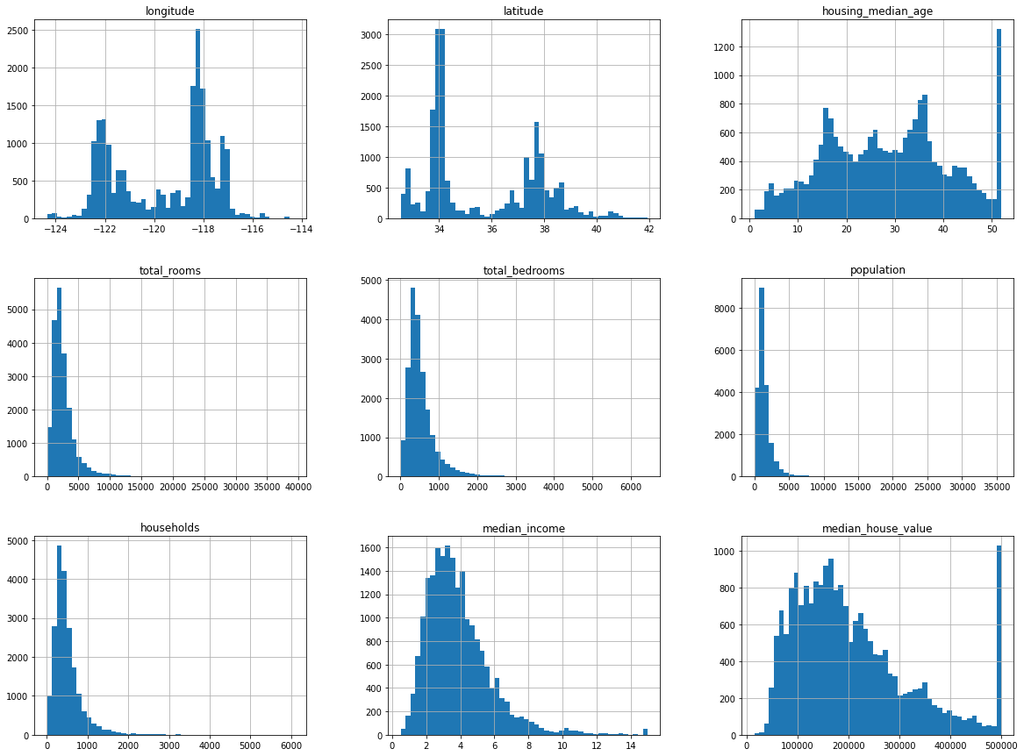

```python
# %matplotlib inline works only in a Jupyter notebook
%matplotlib inline

import matplotlib.pyplot as plt

housing.hist(bins=50, figsize=(20,15))
plt.show()
```

## 4.3.0 Render a map using latitude and longitude values

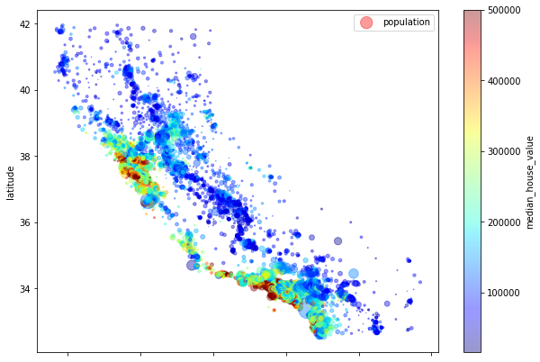

```python
# Make a classic x/y scatter plot
# Use longitude as x and latitude as y
housing.plot(kind="scatter",                                     # What kind of plot is it?
             x="longitude", y="latitude",                        # Set the source of x/y values
             alpha=0.4,                                          # Make our dots a little more transparent
             s=housing["population"]/100, label="population",    # Scale population by 100 and label
             figsize=(10,7),                                     # Set the figure size
             c="median_house_value",                             # Set the colour based on median hour value
             cmap=plt.get_cmap("jet"), colorbar=True,            # Create a colourbar
)
plt.legend()
```

So, from now on, all you need to do to download and work on your data is to define the link to the data warehouse, what directories you want to access, and run **fetch_data()** and **load_data()**

# 5.0.0 Moving into the unknown

Prior to this point, many of our examples involved data that was spoon fed to you. URLs and locations were all predetermined but what if you find yourself in a situation where you don't know where files will be located or how many files you need to download?

In some cases, you would need to read through webpage (HTML) or other encoding to determine information like finding links to data or breaking down twitter usage of hashtags. The act of breaking down these sites and pulling data from them is also known as web scraping.

There are a number of ways to pull data from the web and there are some beautiful packages that can help like:

- [Scrapy](https://scrapy.org/): an extensible language for scraping data
- [Pattern](https://github.com/clips/pattern): a high-level web scraper that can implement natural language processing to identify patterns of interest for analysis.
- [BeautifulSoup](https://www.crummy.com/software/BeautifulSoup/bs4/doc/): a robust package for simple web scraping - especially for beginners!

## 5.1.0 Data scraping with `BeautifulSoup`

From section 4.0.0 we created a series of functions for downloading static datasets but what happens if we want to explore a collective of data sites or multiple parts of the same site? Well structures websites often have a specific style that can be leveraged for analysis by:

1. Generating queries
2. Accessing search results
3. Scraping for links within searches and subsequent pages

### 5.1.1 Install `BeautifulSoup`

Once we install beautiful soup, we can access it through the `bs4` package. We'll also work with another helpful package called `requests`, which we'll use to pull down our data.

```python
# Install the BeautifulSoup package if needed
# !pip install beautifulsoup4

# Import requests and Beautiful soup
import requests
from bs4 import BeautifulSoup
```

## 5.2.0 Try to identify query parameters

Often you may find that when you use searchable websites, they create webpages showing more than just the base URL identifiers. Often the URLs for these search results may contain *query parameters* which are basically like additional tags on the page. They often follow a main URL after a `?=` and contain search terms that are concatenated with a `+` symbol.

For example, if we go to the [Province of Ontario's official data catalogue](https://data.ontario.ca/) we can search for all publicly available datasets.

| The Ontario public data archive has all sorts of information produced by the governemnt of Ontario and associated entities! |
| --- |

Using the search bar on the web page, to look for "covid hospital cases" will produce a results with the following URL: **https://data.ontario.ca/dataset?q=covid+hospital+cases**

In this case, the 3 keywords used in our search were appended to the **https://data.ontario.ca/dataset** directory. With this in hand, we'll see where this rabbit hole goes.

| The Ontario public data archive has all sorts of information produced by the governemnt of Ontario and associated entities! |
| --- |

If we right-click on the top link and "inspect" it, we can see a breakdown of the actual HTML elements that make up the page. We see that search result links lead to new pages but all of them are enclosed under `h3` heading tags. We'll use this to our advantage to isolate all of the links on the results of this first search page. From there, we can visit all the search results that are relevant to what we're really looking for.

First, however, we'll need to import this document into Python for analysis.

### 5.2.1 Use `requests.get()` to create a response

In order to pull down the search results webpage we just identified, we'll use the `requests` packages and it's `get()` function. This function will return a `Response` object with a response code like "200" (good) or "404" (webpage not found). You can retrieve the status using the `status_code` attribute or `ok` (False if a 404 response).

```python
# URLs that don't exist
requests.get("https://data.ontario.ca/data?=covid").status_code
requests.get("https://data.ontario.ca/data?=covid").ok

# URLs that DO exist!
requests.get("https://data.ontario.ca/dataset?=covid").status_code
requests.get("https://data.ontario.ca/dataset?=covid").ok
```

```
404
```

```
False
```

```
200
```

```
True
```

After spelunking around the webpage a bit, we can safely decide on a base URL that we'll use as the root/main web address. From there we can append our query or queries if you were going to search for multiple different sets of data.

```python
# Set up your base URL
BASE_URL = "https://data.ontario.ca"

# We know what the structure of our query URL will look like
QUERY = "/dataset?q=covid+hospital+cases"

# Combine the two strings to make a search request
searchPage = requests.get(BASE_URL+QUERY)

# We should get back a "Response" object
searchPage.ok
```

```
True
```

Take a quick look at the decoded webpage using the `text` attribute. The full encoding of the webpage can also be accessed (in a less human-readable form) using the `content` attribute.

```python
# How can we access the text of the page?
print(searchPage.text)
```

[output not shown]

[output cut: 3130 more lines]

[output not shown]

## 5.3.0 Create a `BeautifulSoup` object

Now that we have downloaded the search webpage into a `Response` object, let's convert it to a `BeautifulSoup` object that will parse through the text of the HTML for us. There are actually many parsers we can use depending on the kind of page we downloaded (HTML, XML, etc). We'll feed our `Response.content` attribute as input.

```python
# Now that you have the page object, you can convert
soup = BeautifulSoup(searchPage.content, "html.parser")
type(soup)
```

```
bs4.BeautifulSoup
```

### 5.3.1 Navigating the `BeautifulSoup` object like a tree with dot notation

Now that we have our beautiful soup object, there are a couple of ways to think about this object. The nature of HTML tags can create different tags nested within others. In our case we identified that links to the pages from our search results are encoded in a structure that looks like:

```
<h3 class="dataset-heading">
    <a href="/dataset/breakdown-of-covid-19-positive-hospital-admissions">Breakdown of COVID-19 positive hospital admissions</a>
    </h3>
```

We can take advantage of this structure to pull out all the instances of the `h3` **tag** keeping the `content` that is enclosed within that tag. You can navigate this kind of **parsed tree** object by using the tag types as attributes to retrieve the *first instance* of a tag like this:

```python
# Pull down the title
soup.title

# Pull down the first h3 header
soup.h3
```

```
<title>Datasets - Ontario Data Catalogue</title>
```

```
<h3 class="dataset-heading">
<a href="/dataset/breakdown-of-covid-19-positive-hospital-admissions">Breakdown of COVID-19 positive hospital admissions</a>
</h3>
```

In fact, you can keep diving deeper using dot (**`.`**) notation on the different sub-tags within. In the case of our `h3` tags, they contain the `a` tag used to represent hyperlinks. The `a` tag has all kinds of **attributes** for how they present [hyperlinks on an HTML page](https://www.w3schools.com/tags/tag_a.asp).

```python
# Pull the link tag information from the first h3 tag
soup.h3.a
```

```
<a href="/dataset/breakdown-of-covid-19-positive-hospital-admissions">Breakdown of COVID-19 positive hospital admissions</a>
```

### 5.3.2 Access the attributes of a `tag` object as a dictionary key

Within the confines of our a tag definition, there may be multiple **attributes**. For instance in our `<a>` tag, we can define an html link using the `href=` attribute. If you are interested in pulling this information specifically, you can use the attribute name as a key and access this with dictionary indexing `[ ]` notation.

```python
# What is the link to the first search hit?
soup.h3.a["href"]
```

```
'/dataset/breakdown-of-covid-19-positive-hospital-admissions'
```

### 5.3.3 Use the `.find_all()` method to search *multiple* instances of a tag

Of course for our purpose we are interested in looking past just the *first* instance of the `h3` tag in our search page. To accomplish this we'll use the `find_all()` method to search our `BeautifulSoup` object for all `h3` tags. This will return a `ResultSet` object that we can iterate over. We'll combine the `ResultSet` with a for loop to tease out all of the `<a href=>` links a dictionary pairing the description text (key) which is held in the `text` property along with the URL (value).

```python
# Start with a blank dictionary
link_dict = {}

# Find all instances of h3
for link in soup.find_all("h3"):
    # From the content within there, identify the "a" tag which precedes a link
    # Link the text within the "a" tag to the actual link under "href="
    link_dict[link.a.text] = link.a["href"]
    # Print those values to see what we are getting!
    print(link.a.text + ": " + link.a["href"])
```

```
Breakdown of COVID-19 positive hospital admissions: /dataset/breakdown-of-covid-19-positive-hospital-admissions
Schools COVID-19 data: /dataset/summary-of-cases-in-schools
Status of COVID-19 cases in Ontario: /dataset/status-of-covid-19-cases-in-ontario
Ontario COVID-19 outbreaks data: /dataset/ontario-covid-19-outbreaks-data
COVID-19 Vaccine Data in Ontario: /dataset/covid-19-vaccine-data-in-ontario
COVID-19 Self-Assessment Tool: /dataset/covid-19-self-assessment-tool
Licensed child care settings COVID-19 data: /dataset/summary-of-cases-in-licensed-child-care-settings
Confirmed positive cases of COVID-19 in Ontario: /dataset/confirmed-positive-cases-of-covid-19-in-ontario
COVID-19 cases in hospital and ICU, by Ontario Health (OH) region: /dataset/covid-19-cases-in-hospital-and-icu-by-ontario-health-region
Deaths Involving COVID-19 by Vaccination Status: /dataset/deaths-involving-covid-19-by-vaccination-status
Long-Term Care Home COVID-19 Data: /dataset/long-term-care-home-covid-19-data
Deaths Involving COVID-19 by Fatality Type: /dataset/deaths-involving-covid-19-by-fatality-type
Status of COVID-19 cases in Ontario’s Provincial Correctional Institutions: /dataset/status-of-covid-19-cases-in-ontario-s-correctional-institutions
Status of COVID-19 cases in Ontario by Public Health Unit (PHU): /dataset/status-of-covid-19-cases-in-ontario-by-public-health-unit-phu
COVID-19 testing of inmates in Ontario’s Provincial Correctional Institutions: /dataset/covid-19-testing-of-inmates-in-ontario-s-correctional-institutions
Availability of adult and pediatric ICU beds and occupancy for COVID-related ...: /dataset/availability-of-adult-icu-beds-and-occupancy-for-covid-related-critical-illness-crci
Case-by-Case Review Program (CBCRP) data: /dataset/case-by-case-review-program-cbcrp-data
Discharge Abstract Database (DAD) / Ontario hospitals: /dataset/discharge-abstract-database-dad-ontario-hospitals
Ontario Case Costing Initiative (OCCI): /dataset/ontario-case-costing-initiative-occi
Incident cancer case level stage data: /dataset/incident-cancer-case-level-stage-data
```

## 5.4.0 Narrow your search results

Now that we have the individual result hits from the search page stored in a dictionary (along with its description), we can search through our keys for which ones really match what we want. In this case, we'll narrow down the hits with the keyword "hospital" using a list comprehension to store the results.

We'll also use a filtering `if` in this step to only return matching hits so we end up with URLs to pages concerning hospital data. Recall our results are currently stored in `link_dict` and we can use the `re.search()` function to match for keyword patterns in each dictionary key.

```python
import re

# Begin a search of our keywords, looking for "hospital"
hospitalData_URLs = [link_dict[link_name]                         # Keep the value for keys that pass filter
                     for link_name in list(link_dict.keys())      # Iterate through each dictionary key
                     if re.search("hospital", link_name) != None] # Search for our pattern and filter for match found

# Which result pages are we actually interested in?
hospitalData_URLs
```

```
['/dataset/breakdown-of-covid-19-positive-hospital-admissions',
 '/dataset/covid-19-cases-in-hospital-and-icu-by-ontario-health-region',
 '/dataset/discharge-abstract-database-dad-ontario-hospitals']
```

## 5.5.0 Search our results for data to download!

We're down to our last few steps. We now have a list of viable search result pages and on each of these there *may* be data that we can download for later analysis. We'll have to repeat some of our previous steps to parse through these results hits for links to data files. In this case, we'll look for CSV, TSV, and TXT files.

We'll use a combination of both `for` loops to visit each page in our `hospitalData_URLs` object. We'll parse each with `BeautifulSoup` and then use list comprehension to check the links on that page for our file types of interest.

```python
# Begin to collect the data links
data_links = []

# Retrieve any csv, tsv, or txt files
for data in hospitalData_URLs:

    # Build the base URL
    data_URL = BASE_URL+data

    # Pull down the page
    data_page = requests.get(data_URL)

    # Convert it to a BeautifulSoup object
    data_soup = BeautifulSoup(data_page.content, "html.parser")

    # Search for any links to the 3 file types
    data_links = data_links + [link["href"]                          # Retain the link
                               for link in data_soup.find_all("a")   # From each link on the page
                               if re.search(r'\.csv\Z|\.tsv\Z|\.txt\Z', link["href"]) != None] # If it leads to a file!

# How many files do we actually have to download?
data_links
```

```
['https://data.ontario.ca/dataset/8033f5df-6db8-41fe-921a-5f1160b4d75b/resource/d1199d1b-dc82-4e63-bb80-5c715e97a127/download/hosp_icu_c19_breakdown.csv',
 'https://data.ontario.ca/dataset/8f3a449b-bde5-4631-ada6-8bd94dbc7d15/resource/e760480e-1f95-4634-a923-98161cfb02fa/download/region_hospital_icu_covid_data.csv']
```

## 5.6.0 Download your data!

We're in our final steps now. From the steps above, you'll see that we now have a complex URL pointing to data that we'd like to download. We just need two things to do it properly:

1. A URL to download *from*.
2. A file path to download *to*.

To create our file path we'll strip away the excess URL information and just get the file name. Recall the `re.split()` function can help us out here. The file name will be in the last part of our split results if done properly!

We'll also make a directory to save it to before we download the files. Then we just need one last `for` loop to help us iterate through all of the download files!

```python
# Now we want to download the data and save it to a data folder
[re.split(r'/', link)[-1] for link in data_links]

# If the download directory doesn't exist
if not os.path.exists('dataScrape'):
    # Make the directory
    os.mkdir('dataScrape')

# Iterate through the links you collected
for link in data_links:
    # Identify the file name - it should be after the last "/"!
    download_path = 'dataScrape/' + re.split(r'/', link)[-1]
    print(download_path)

    # Pull down the URL and save it to download_path
    urllib.request.urlretrieve(link, download_path)
```

```
['hosp_icu_c19_breakdown.csv', 'region_hospital_icu_covid_data.csv']
```

```
dataScrape/hosp_icu_c19_breakdown.csv
```

```
('dataScrape/hosp_icu_c19_breakdown.csv',
 <http.client.HTTPMessage at 0x19a9ac08f40>)
```

```
dataScrape/region_hospital_icu_covid_data.csv
```

```
('dataScrape/region_hospital_icu_covid_data.csv',
 <http.client.HTTPMessage at 0x19a9ac09d20>)
```

That's it! We've successfully scraped our data. With a little more time we could convert this into a function to scrape the Ontario Data site for whatever we're interested in!

**Learn more about data scraping:** We had a quick example of how to build a data scraper in Python but for a more detailed tutorial, you can [check out this one at realpython.com](https://realpython.com/beautiful-soup-web-scraper-python/).

## 5.7.0 Is this the end?

Throughout this entire course, we've been focused on just getting the basics of Python. To review some of the topics we've covered include:

1. Basic Python objects, packages, and operations.
2. Python data structures: lists, dictionaries, arrays, and DataFrames.
3. Python data formatting and wrangling.
4. Exploratory data analysis and visualizations.
5. String manipulation and matching with regular expressions.
6. Flow control with looping and branching code.
7. Creating your own user-defined functions.

All of these topics help to build a foundation for analysing your data but also provide you with an understanding of the Python language so you can move forward with learning new packages that are relevant to your own research. For instance, knowing what a list or tuple is or how to unpack an interable will simplify learning new coding paradigms.

| All good things must come to an end eventually... or sometimes they just change! |
| --- |

*Our* journey together is over - for this class. Unfortunately we left a *lot* out of this course that you might find useful! We barely covered topics like:

- Data Visualization
- Statistical analysis
- Working with the OS and other programs
- Data scraping from websites
- How to combine Python with other helpful languages like R (**Appendix 2!**).

And we didn't even touch on things like:

- BioPython and other bioinformatics packages
- Using Python for machine learning.
- And [more...](https://generalassemb.ly/blog/how-is-python-used-in-data-science/)

# 6.0.0 Class summary

That's our seventh and final class on Python! We worked through a lot of important steps for building and using our own functions. To summarize, we've covered:

1. Creating user-defined functions.
2. Scoping your variables.
3. Decoding user-defined functions from previous lectures.
4. Building your own user-defined function to automate tasks.
5. Using `rpy2` to combine Python and R.

**Best of luck with your data science journey!!**

## 6.1.0 Submit your completed skeleton notebook (2% of final grade)

At the end of this lecture a Quercus assignment portal will be available to submit your completed skeletons from today (including the comprehension question answers!). These will be due one week later, before the next lecture. Each lecture skeleton is worth 2% of your final grade but a **bonus 0.7%** will also be awarded for submissions made within 24 hours from the end of lecture (ie 1300 hours the following day).

## 6.2.0 Post-lecture DataCamp assessment (8% of final grade)

Soon after the end of this lecture, a homework assignment will be available for you in [DataCamp](https://www.datacamp.com/). Your assignment is to complete chapters 1-3 (Best Practices, 750 possible points; Context Managers, 800 possible points; and Decorators, 1050 possible points) from the Writing Functions in Python course. This is a pass-fail assignment, and in order to pass you need to achieve a least 1950 points (75%) of the total possible points. Note that when you take hints from the DataCamp chapter, it will reduce your total earned points for that chapter.

In order to properly assess your progress on DataCamp, at the end of each chapter, please print a PDF of the summary. Navigate to the **`Learn`** section along the top menu bar of DataCamp. This will bring you to the various course you have been assigned under **`My Assignments`**. You can click on your completed assignment and expand each **chapter** of the course by clicking on the **`VIEW CHAPTER DETAILS`** link. Do this for all sections on the page and then select all on the page (ie `ctrl + A`). Go to print the page from your browser menu you can save as a single PDF. If you don't try to select all (at least in Google Chrome) you may not be able to print the full page.

Submit the file(s) for the homework to the assignment section of Quercus. This allows us to keep track of your progress while also producing a standardized way for you to check on your assignment "grades" throughout the course.

You will have until 09:59 hours on Tuesday, February 21st to submit your assignment (right before the next lecture).

| A sample screen shot for one of the DataCamp assignments. You'll want to try and print off a single PDF of this section from **Learn > My Assignments** |
| --- |

## 6.3.0 Final assignment guidelines (30% of final grade)

1. Your Jupyter Notebook final project
2. A PDF version of the notebook with all output from the code cell. This will be used for markup and comments that I can return to you about your projects.
3. Any associated data needed to run your project. When you create your compressed file for submission, you can preserve the folder structure by compressing the entire folder with the needed files.
4. KEEP YOUR INPUT/DATA SUBMISSION UNDER 100 Mb. These can be used to help re-run your code if inconsistencies are identified but please generate a subset of your data if it is excessively large.

[figure not shown]

Please refer to the marking rubric found in your lecture notes for additional instructions and FAQs.

You can build your Jupyter Notebooks on the UofT JupyterHub and save/download a compressed archive to your personal computer for before submitting on Quercus.

Any additional questions can be emailed me to or posted to the Discussion section of Quercus. Best of luck!

| Don't forget to submit your term project! |
| --- |

## 6.4.0 Post-course survey

Remember your DataCamp accounts will continue to remain active for another ~4 months during which time you can choose to explore the site's different courses. Please take advantage of this opportunity to keep growing your Python or other data science skills!

We have also created a post-course survey you can fill out anonymously. You can use this survey as an opportunity to tell us about your experience and help shape the future offerings of this series. Please take 5-10 minutes to fill out the survey. We really appreciate your feedback!

[Anonymous Google Survey found here](https://forms.gle/ZT3BKMZx22jwz6Jp7)

## 6.5.0 Acknowledgements

**Revision 1.0.0**: materials prepared by Oscar Montoya, M.Sc. *Bioinformatician, Education and Outreach, CAGEF.*

**Revision 1.1.0**: edited and prepared for **CSB1021H S LEC0140**, 06-2021 by Calvin Mok, Ph.D. *Bioinformatician, Education and Outreach, CAGEF.*

**Revision 1.2.0**: edited and prepared for **CSB1021H S LEC0140**, 01-2022 by Calvin Mok, Ph.D. *Bioinformatician, Education and Outreach, CAGEF.*

**Revision 1.2.1**: edited and prepared for **CSB1021H S LEC0140**, 01-2023 by Calvin Mok, Ph.D. *Bioinformatician, Education and Outreach, CAGEF.*

## 6.6.0 Resources

- https://campus.datacamp.com/courses/writing-functions-in-python/best-practices?ex=1
- https://campus.datacamp.com/courses/writing-functions-in-python/best-practices?ex=5
- https://realpython.com/primer-on-python-decorators/
- https://generalassemb.ly/blog/how-is-python-used-in-data-science/

# 7.0.0 Appendix 1: context managers

In the context of scope and memory, context managers allow you to create variables and manipulate objects in a way that ensures their memory footprint doesn't pollute your global environment. This can happen in a number of cases where Python opens a connection or generates a resource but then you forget to close it or during the course of that code-block an exception or error is encountered. In those cases, you may inadvertantly "lose" the connection but it is not destroyed by Python. This remaining connection produces a "memory leak" as it cannot be properly removed from the programs memory. It may also prevent you from re-opening the same connection or altering a file later outside of Python.

There are two main ways to dealing with this, the `try/finally` exception structure or a **context manager**. We won't go over all of the details but in both cases, when you wish to use a resource you usually:

1. Allocate/initialize the resource.
2. Read/Write/Transform the resource.
3. Close or de-allocate the resource.

When your code runs, an error at step 2, may skip step 3 altogether. The `try/finally` statements encapsulate your code to ensure that if an error while `try`ing step 2 occurs, it will still close the file when you are `finally` done.

Similarly, a **context manager** is a pre-formed version of this, where common Python actions are coded to catch errors and "recover gracefully". Context managers avoid having to produce additional complicated code and take the form:

```python
with <context-manager>(<args>) as target:
    # your code involving target
    # code is running inside this context

# This code runs after the context is removed. Notice that this line is not indented
```

The keyword `with` signals to Python the use of a context manager. If the context manager produces an object, like a file connect, the optional keyword `as` assigns the resulting manager to the variable `target`.

Here is an example of the context manager `open` to import a file and perform some operations on it.

```python
# Use a context manager to open a file
with open('data/sequences.tsv') as file:
    # Read the file in from the connection
    file_text = file.read()
    file_text_length = len(file_text)

print("The hmp file has {} characters".format(file_text_length))
```

### 7.0.1 The context manager cleans up for you after leaving the indentation group

From the above code, under the hood, when we leave the indentation group and print out our information, the context manager closes the file connection. If for some reason, we called on an incorrect method, we might be returned a warning or exception that could end the program. Before the kernel exits the program, however, the context manager's code would execute an `__exit__` method which includes shutting down the file connection. Therefore the file is not occupying space in memory anymore!

## 7.1.0 Defining context managers with your own function

Context managers are pre-made functions that have certain assumptions about the order of how actions *should be* performed. While some are relatively simple like the `open` command, you may find yourself in a situation where you have specific needs.

You can use context managers to manage paired action patterns that you use often like:

- Open & Close
- Start & Stop
- Lock & Release
- Change & Reset
- Enter & Exit

You may be building a function where your expect a certain data format or style. To use context managers inside a function, you need to define it like you would define a function. At the end of the function, use the keyword `yield` followed by any code that would help clean up the context (optional).

Cleanup code can be a piece of code that, for example, disconnects from a remote database after you are finished using it. An easy way to build context managers is with the `@contextlib.contextmanager` decorator right above the context manager.

**Decorator syntax:** In Python, the decorator syntax **@** is a fancy way of saying "Pass function_A to @function_B to run inside function_B." Whenever you call on function_A it will redirect into function_B, which tends to *extend* the function of function_A. This action is also known as [wrapping](https://realpython.com/primer-on-python-decorators/).

Let's take a look at the format.

```python
# Import the contextLib package
import contextlib
```

```python
# Use the @ sytax to signify the wrapper function is contextmanager
@contextlib.contextmanager
def my_contextn():
    # here goes your code
    yield
    # add any code that you need to clean up the context
```

### 7.1.1 The `yield` statement is where the cleanup happens

The `yield` statement tells Python that you want to return a value but that you will finish the rest of the function afterwards. More importantly, this statement saves the state of the local variables. Remember what we talked about with scoping? When we `yield` a function, it's scope and state are saved. Returning to the function picks back up where it was the `yield` was called. For a context manager, we can include this call **only once**. The `contextmanager` wrapper is coded specifically to look for this structure to initiate your function cleanup.

Here is a more useful example of how to use a context manager. Let's say that you have set your working directory, but sometimes you need to access files outside your current working directory. Let's write a context manager that changes the current working directory, performs a tasks, and changes the path back to your previously set working directory.

```python
# Import the os package
import os

os.getcwd() # current working directory
```

```python
#import contextlib

# Decorate our function
@contextlib.contextmanager
# Define our function in_dir() which takes a parameter: path
def in_dir(path):
    old_dir = os.getcwd() # The current working directory
    os.chdir(path) # The alternative directory we want to use

    yield # When the contextmanager object uses __exit__, it will come here

    # and change the current directory back to the original!
    os.chdir(old_dir)
```

Let's see the context manager in action!

```python
# Use our context manager now using the "with"
with in_dir('../Lecture_06_Regex/data/') as lec_6:
    # What is lec_6?
    type(lec_6)

    # Take the path and list what is in that directory using the os.listdir command
    data_files = os.listdir()

    # Print the results of that directory
    print("Current directory:", os.getcwd(), end="\n\n")
    print("Files:", data_files, end="\n\n")

# What was our original directory?
print("Original directory:", os.getcwd())
```

[output not shown]

### 7.1.2 Your context manager can return a `None` object

More importantly, the context manager works and your current working directory is intact!

# 8.0.0 Appendix 2: compiling other languages in python

## 8.1.0 Run R code in Python with `rpy2`

While Python is very dynamic with a wide number of packages available, sometimes you might feel more comfortable working with something familiar. For instance, the `ggplot2` package is *de facto* visualization package in R. Additional packages are built with `ggplot2` as a basis, expanding on it's grammar-of-graphics style. Of course there is a relatively recent Python version of this package called `plotnine`. Comparing these two, there is an active community of [over 250 contributors](https://github.com/tidyverse/ggplot2/graphs/contributors) working on `ggplot2` to update and improve it on a regular basis while `plotnine` is developed and maintained [by a single individual](https://plotnine.readthedocs.io/en/stable/api.html).

Taking that into account, you may want to visualize your data with R rather than python! The same could be said for other standard bioinformatics packages from R, whose functionality might be useful, like `DeSeq2` for differential expression analysis of RNA-Seq data.

Rather than splitting your time *between* two programming languages, and their development environments, you can run it all from a single script with the `rpy2` package. Let's look at the two ways we can use this package to our advantage.

```python
# Install the rpy2 package
!pip install rpy2
```

```python
# Import pandas and numpy
import pandas as pd
import numpy as np
import re

# Load the pitlatrine data
embryo_merged_all = pd.read_csv("data/embryo_long_merged.csv")

# Subset the data from our dataset
embryo_merged_subset = embryo_merged_all.iloc[:, :19]

# What does the subset look like?
embryo_merged_subset.info()
```

```python
# 1. Update the column names
# Remove all of the "M" characters in the pathogenDose column
embryo_merged_subset = embryo_merged_subset.replace(to_replace = {'pathogenDose': {'M':''}},
                                                    # Set regular expressions to true
                                                    regex = True,
                                                    # Set the data types for the updated columns
                                                   ).astype({'pathogenDose':'float'})

# 2. Fix the column names
# a. Remove the "." and remember the "\" to treat it as a literal!
data_cols = [re.sub(pattern = r'\.', repl = " ", string = colname) for colname in embryo_merged_subset.columns.tolist()]

# b. Convert all non-first words to start with uppercase
data_cols = [re.sub(pattern = r'\s\b\w',
                    repl = lambda x: x.group().upper(),
                    string = colname
                   ) for colname in data_cols]

# c. Convert all first words to lowercase
data_cols = [re.sub(pattern = r'^\w',
                    repl = lambda x: x.group().lower(),
                    string = colname
                   ) for colname in data_cols]

# d. Remove spaces and closing parentheses
data_cols = [re.sub(pattern = r'\s', repl = "", string = colname) for colname in data_cols]

# Assign the resulting list
embryo_merged_subset.columns = data_cols

# Check the final results
embryo_merged_subset.head()
```

Summarize our data using the `groupby` and `agg` paradigms.

```python
# Filter for only uninfected data
mean_embryo_data = (embryo_merged_subset.loc[embryo_merged_subset['doseLevel'].
                                             isin(values = ["Mock", "Medium"])] # filter by doseLevel

                    # Group by infection experiment
                    .groupby(by = ['date', 'wormStrain', 'pathogenStrain', 'doseLevel'])

                    # Create the frequency table on numEmbryos
                    ['numEmbryos']
                    .agg('mean')

                    # Recall, when we reset the index, it converts the indices back into columns
                    .reset_index()

                    .astype({'doseLevel':'category'})
)

# Check out our summarized data
mean_embryo_data
```

### 8.1.1 Use `rpy2` to import packages from the R library

To begin with, the `rpy2` package provides a function `importr` that allows you to import `R` packages for use in Python by assigning them to variables/aliases. For everything to work, we'll actually need to import a number of packages and modules. More specifically we'll be importing:

- `rpy.robjects`: This will give us the ability to directly access base `R` objects and values like `pi`.
- `rpy2.robjects.packages.importr`: This will provide us with functionality to import other R packages.

```python
# Begin by importing the R objects handler
import rpy2.robjects as ro
# Import the `rpy2` importer
from rpy2.robjects.packages import importr

# Import some basic functions for R
base = importr('base')
utils = importr('utils')
```

```python
# We can access basic R values like pi
base.pi

# Or check on our current directory
print(base.getwd())
```

### 8.1.2 Converting `pandas.DataFrame` to R `data.frame`

While the `pandas` and base `R` versions of data frame objects share significant overlap in behaviour and design, they are still distinct object types. In order to use R packages, we'll have to make the conversion from one to the other. This, itself, involves 2 additional modules. For the purpose of making our code concise, we will import the specific modules we want:

- `rpy2.robjects.pandas2ri`: This package is necessary for converting our `pandas` objects like `DataFrames` to `R` `dataframe` objects.
- `rpy2.robjects.conversion.localconverter`: A context manager (see Section 7: Appendix 1) that is required for `rpy2` to limit the scope of conversion.

```python
# Import a specific DataFrame converter between pandas and R
from rpy2.robjects import pandas2ri
# Import a context manager that allows the conversion to be completed properly (See Appendix 1!)
from rpy2.robjects.conversion import localconverter
```

```python
# What kind of object is our filtered data?
type(mean_embryo_data)

# This is a context manager which is REQUIRED to properly open convert between data frame versions
with localconverter(ro.default_converter + pandas2ri.converter):
    r_mean_embryo_data = ro.conversion.py2rpy(mean_embryo_data)

# What do we have now?
type(r_mean_embryo_data)

# What are the properties of our dataframe?
utils.str(r_mean_embryo_data)
```

### 8.1.3 Import packages required for plotting your data

Now that we have our data converted to an R-based `data.frame` we can proceed to plotting it. Here we'll import the packages we'll need to plot the data and display it:

- `rpy2.robjects.lib.ggplot2`: Rather than import ggplot2 directly, we'll go through the `rpy2` package. It's basically a wrapper that calls on the `importr()` function. Unfortunately we need this to help cover some functionality we can't reach regularly through a command like `importr(ggplot2)`
- `rpy2.robjects.lib.grdevices`: Again a way to access the graphics devices that we'll need to print our plot. This has more to do with rendering our plots in Jupyter Notebook.
- `IPython.display.Image` and `IPython.display.display`: to handle the display of our plots in your Jupyter Notebook.

```python
# Import ggplot2 but just let it float in the background. We'll only passively use this.
import rpy2.robjects.lib.ggplot2 as ggplot2rpy2

# Access the graphics display drivers for R
from rpy2.robjects.lib import grdevices

# Access display properties of the Jupyter Notebook
from IPython.display import Image, display
```

### 8.1.4 Plot your data using `ggplot2`

Now that we've set up all of the necessary components, we can go ahead and plot our data. We'll do this again within the confines of a context manager `grdevices.render_to_bytesio()`. This will ensure that, should something go wrong, the various connections created will be quietly closed without creating additional memory leaks.

In our context manager, we'll set the width and height of our image as well to produce an object called `img` that will hold the resulting plot information.

You'll also notice in our code that any `ggplot2` functions normally loaded into memory in R, must be called with dot (`.`) notation in the normal Python style.

```python
# Import the ggplot2 library
# ggplot2 = importr('ggplot2')

# Build and display a plot, but pass all that information on to img
with grdevices.render_to_bytesio(grdevices.png, width=700, height=700, res=150) as img:
    # Save our plot as an object
    # 1. Data
    gp = (ggplot2rpy2.ggplot(r_mean_embryo_data) +
          # 2. Aesthetics
          # Set the x and y axis data
          ggplot2rpy2.aes_string(x='wormStrain', y='numEmbryos') +

          # Change the x-axis text angle and size
          # ggplot2.theme(text = ggplot2.element_text(family = "Arial", size=7)) +
          ggplot2rpy2.theme_minimal(base_family = "Arial") +
          ggplot2rpy2.theme(axis_text_x = ggplot2rpy2.element_text(angle = 90, size = 7),
                        text = ggplot2rpy2.element_text(size = 7)) +

          # 4. Geom
          ggplot2rpy2.geom_boxplot())    # Use a boxplot

    gp.plot()

# Display the plot via the code cell using IPython
display(Image(data=img.getvalue(), format='png', embed=True))
```

[output not shown]

## 8.2.0 Using IPython magic to work with R

What a wild ride! We used `import` to bring in or alias eight different modules and components to make our graph. While many of those were use *just* to display our plot in the Jupyter notebook. While this will certainly not be the case within a simpler Python script, there are still many nuances involved with making this work.

Under the hood of the Jupyter Notebook, there are a number of IPython-specific *magics*. These are essentially syntactic shortcuts beginning with `%` that allow you to perform quick operations or directives involving your code. In our case, what we are really interested in is making our life with using `R` in `Python` just a little simpler.

### 8.2.1 Load an IPython extension with `%load_ext`

The IPython extensions are just what they sound like. Recall that our Jupyter Notebooks are built on an IPython shell which controls how we access Python and output the code we run. We have already seen an example of modifying this command via the `IPython.core.interactiveshell`. Extensions add extra modifications to the behaviour of this shell and we can add more using the magic command `%load_ext <extension_name>`.

To gain access to the `rpy2` package and it's capabilities, we can use the extension `rpy2.ipython`.

```python
# Load the rpy2.ipython extension
%load_ext rpy2.ipython
```

### 8.2.2 Run R in-line with your Python code via `%R`

Sometimes you may wish to simply slip in some R code between calculations or lines in your Python code. Perhaps you want to access a package and generate a quick calculation in R. Do this with `%R` to let Python know your intent. Along with this magic comes a series of possible parameters including:

- `-i <input>`: An opportunity to pass in a variable and automatically convert it to an equivalent object in R. This applies to dataframes as well!
- `-o <output>`: Prepare to convert an R object from your upcoming code to an equivalently named Python object.
- `-w <width>` and `-h <height>`: The width or height of your plotting device. Especially helpful when generating plots.

```python
# Take a look at the data
mean_embryo_data.head()

# calculate the mean embryos across all strains in R and pass it back
%R -i mean_embryo_data -o embryo_mean embryo_mean = mean(mean_embryo_data$numEmbryos)

# Now print it in Python
print(embryo_mean)
```

### 8.2.3 Convert whole code cells to R using `%%R`

When you are generating or running large portions of code, you can convert the whole code cell to work through `rpy2` using the `%%R` magic. It works with the same parameters as `%R` to simplify the process.

Let's use this to create a code cell where we plot our data as above. Since we are plotting, we'll set the width and height of our plotting device at the same time.

```python
%%R -i mean_embryo_data -w 800 -h 600

library(ggplot2)
pl = ggplot(mean_embryo_data) +
    # 2. Aesthetics
    aes(x = wormStrain, y = numEmbryos) +
    theme_grey(base_family = "Arial") +
    theme(axis.text.x = element_text(angle = 90)) +

    # 4. Geoms
    geom_boxplot()

pl
```

**The magic was in You**(r IPython Jupyter Notebook) **all along:** While we've covered just how to run R through the magics, you can actually convert coding cells to run all sorts of languages - bash scripts, perl, Java and more! There are also many helpful shortcuts for quickly navigating different aspects of your Jupyter Notebook. You can find out more in the [available documentation](https://ipython.readthedocs.io/en/stable/interactive/magics.html)

## The Center for the Analysis of Genome Evolution and Function (CAGEF)

The Centre for the Analysis of Genome Evolution and Function (CAGEF) at the University of Toronto offers comprehensive experimental design, research, and analysis services in microbiome and metagenomic studies, genomics, proteomics, and bioinformatics.

From targeted DNA amplicon sequencing to transcriptomes, whole genomes, and metagenomes, from protein identification to post-translational modification, CAGEF has the tools and knowledge to support your research. Our state-of-the-art facility and experienced research staff provide a broad range of services, including both standard analyses and techniques developed by our team. In particular, we have special expertise in microbial, plant, and environmental systems.

For more information about us and the services we offer, please visit https://www.cagef.utoronto.ca/.

[figure not shown]